# Preliminary Check

Chenming Ran

4/26/2020

## Data Description

In general, a gravity model assumes that the volume of trade between any two economies will be directly proportional to the product of their economic masses that are commonly measured by GDP or GNP. For predicting aggregate bilateral trade, the aggregate GDP value is the suitable proxy in term of cross-country time-series data. While Circlaeys et al.(2017) used nominal GDP, this study uses trade quantity and real GDP for estimation, which is universally recognized as a more accurate measure of production output

Although “Tradhist” from Centre d’Etudes Prospectives et d’Informations Internationales (CEPII) is the original database used by Circlaeys et al. (2017), the data is only available up to the year 2014. Different from Circlaeys et al. (2017) analyzing bilateral trade flow from 2009 to 2014, I analyze bilateral trade from 1995 to 2018, so key indicators of Bilateral trade flow and GDP will be recreated and updated. Time-invariant indicators, including weighted distances and other control variables, will be adopted from “Tradehist”.

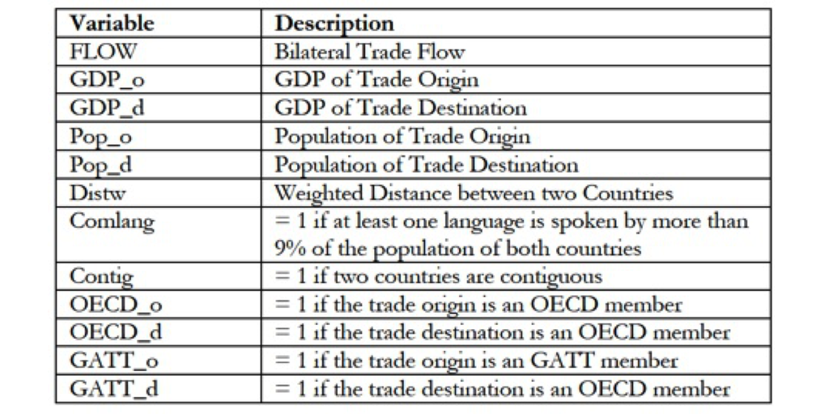

To avoid abnormalities in data and potential obstacles in the process of prediction, first I remove incomplete data from the data set, which means data points that have missing feature values.

|  | FLOW | GDP_o | GDP_d | pop_o | pop_d | distw |
| --- | --- | --- | --- | --- | --- | --- |
|  | Min. :1.000e+03 | Min. :1.049e+07 | Min. :1.049e+07 | Min. :9.298e+03 | Min. :9.298e+03 | Min. : 94.27 |
|  | 1st Qu.:1.829e+05 | 1st Qu.:9.374e+09 | 1st Qu.:7.177e+09 | 1st Qu.:3.836e+06 | 1st Qu.:3.349e+06 | 1st Qu.: 3742.38 |
|  | Median :3.461e+06 | Median :4.631e+10 | Median :3.720e+10 | Median :1.023e+07 | Median :9.814e+06 | Median : 6756.30 |
|  | Mean :5.237e+08 | Mean :4.400e+11 | Mean :4.228e+11 | Mean :5.040e+07 | Mean :4.764e+07 | Mean : 7282.88 |
|  | 3rd Qu.:4.982e+07 | 3rd Qu.:2.499e+11 | 3rd Qu.:2.319e+11 | 3rd Qu.:3.603e+07 | 3rd Qu.:3.269e+07 | 3rd Qu.:10169.23 |
|  | Max. :4.995e+11 | Max. :2.006e+13 | Max. :2.006e+13 | Max. :1.393e+09 | Max. :1.393e+09 | Max. :19735.32 |

Second, I take the log of trade value, GDP, distance and population to achieve a smoother distribution of the data. The distribution is approximately normal which fits the assumptions of linear regression and K-Nearest Neighbors. CART analysis does not assume a particular form of relationship between the independent and dependent variables, but variables still need to be logatrithsms so to avoid bias when comparing RMSEs.

|  | lflow | lgdp_o | lgdp_d | lpop_o | lpop_d | ldistw |
| --- | --- | --- | --- | --- | --- | --- |
| median | 15.0571157 | 24.5586985 | 24.3395250 | 16.1404850 | 16.0993228 | 8.8182306 |
| mean | 14.9582987 | 24.5487492 | 24.3643355 | 16.0959832 | 15.9451927 | 8.6436007 |
| SE.mean | 0.0053559 | 0.0032673 | 0.0033890 | 0.0027284 | 0.0028919 | 0.0011440 |
| CI.mean.0.95 | 0.0104975 | 0.0064038 | 0.0066423 | 0.0053476 | 0.0056680 | 0.0022422 |
| var | 14.1829251 | 5.2780926 | 5.6784711 | 3.6805297 | 4.1348382 | 0.6470871 |
| std.dev | 3.7660225 | 2.2974100 | 2.3829543 | 1.9184707 | 2.0334302 | 0.8044172 |
| coef.var | 0.2517681 | 0.0935856 | 0.0978050 | 0.1191894 | 0.1275262 | 0.0930651 |

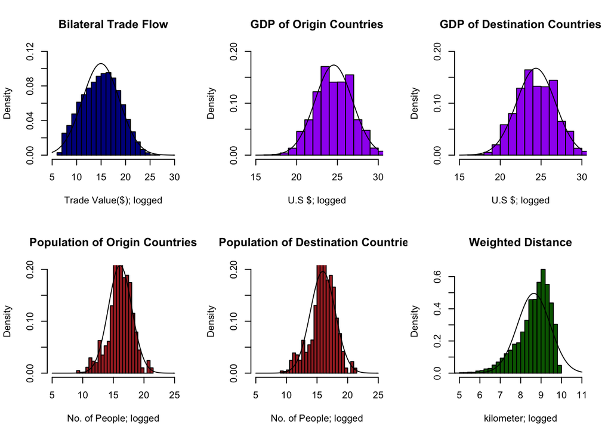

The graph shows that there are some heterogenieties of bilateral trade flow over time, whereas most of the changes are persistent. Therefore, in the next section, I apply autocorrelation and partial-autocorrelation to test whether lagged variable is needed for performing time-series effect.

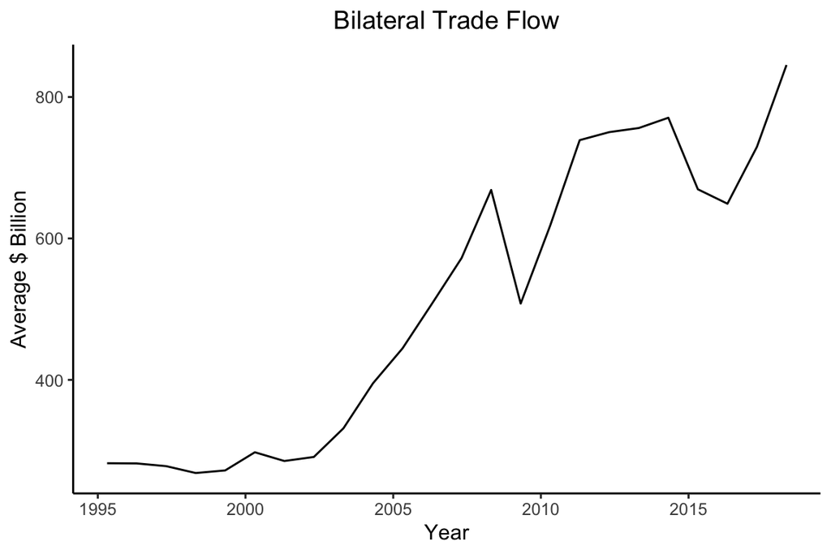

### Autocorrelation and Partial-Autocorrelation

```
##
##  Augmented Dickey-Fuller Test
##
## data:  bitrade$FLOW
## Dickey-Fuller = -47.767, Lag order = 79, p-value = 0.01
## alternative hypothesis: stationary
```

```
##
##  KPSS Test for Level Stationarity
##
## data:  bitrade$FLOW
## KPSS Level = 29.044, Truncation lag parameter = 33, p-value = 0.01
```

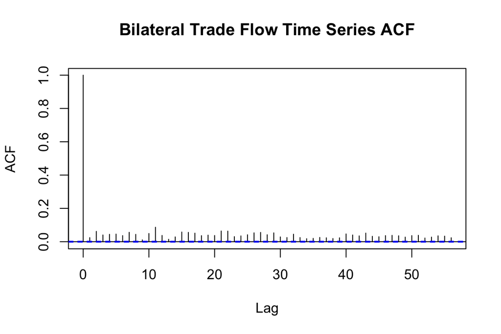

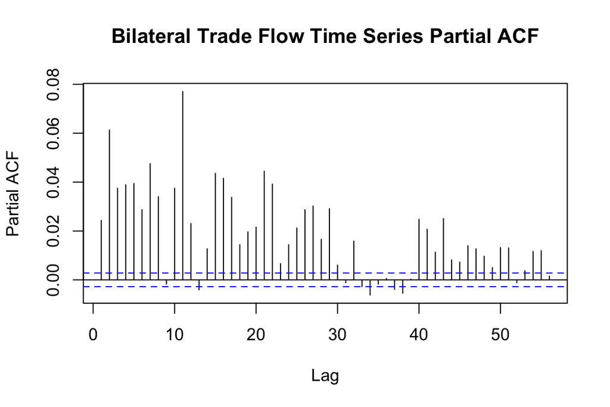

## Emprical Model

As discussed above, Gravity Model describes the interactions among the GDPs and distance in a functional form inspired by Newton’s law of universal gravitation. Becuase, the change of bilateral trade flow is almost persistent over time, a traditional time series model including one lag of trade flow will be tested. The equation shows as below:

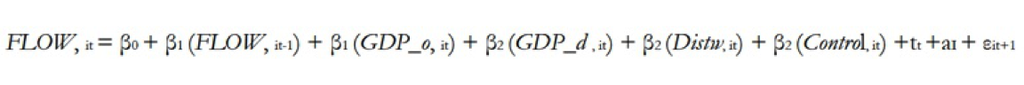

Control features are discussed above and were used by by Circlaeys et al. (2017), including population, share of language, contiguity, OECD, GATT are also. For model estimation, I test the model using three different Machine Learning (ML) techniques, including Linear Regression with Autogressive Model, CART Regression Model and K-Nearest Neighbors algorithm, in order to compare the performance of the linear time-series model against the other ML models.

## Comparison Metrics and Validation Method

Following Circlaeys et al.(2017), R-squared is used as the main metric to compare the predictive performances of our models, which is commonly used as a measure for goodness of fit. I also show Root Mean Square Error (RMSE), another comparison metric, to demonstrate the quality of fit.

According to Circlaeys et al.(2017), since I have enough data, I can conduct a hold-out validation using 30% of the entire data set. This means to separate the data set into a training set and a test set instead of conducting k-fold validation. The original data set is separated into the train set of 346,094 examples (70%) and test set of 148,326 examples (30%).

```r
set.seed(20200302)
split <- initial_split(data = bitrade, prop = 0.7)
bit_training <- training(split)
bit_testing <- testing(split)
```

## Reference

[1] S. Circlaeys, C. Kanitkar, and D. Kumazawa, “Bilateral Trade Flow Prediction”, available at: http://cs229.stanford.edu/proj2017/finalreports/5240224.pdf, 2017